# A Benchmark for Biomedical Knowledge Graph based Similarity

This notebook will guide you through the evaluation of semantic similarity measures. [GitHub](https://github.com/liseda-lab/kgsim-benchmark/tree/master) explains how to use the benchmark data sets for calculation and evaluation of semantic similarity measures.

1. Importing libraries
2. Selecting datasets
3. Correlation calculation
4. Correlation plotting
5. Protein-protein interaction prediction

### 1. Importing libraries

**In this notebook, [Python 3](https://www.python.org), [Jupyter Notebook](http://jupyter.org) as well as the Python libraries Pandas, NumPy, Scikit-learn, Matplotlib and SciPy are used.**

You should have [Anaconda](https://www.anaconda.com) installed in your computer, which already installs Python 3, Jupyter, Scikit-learn, Pandas, NumPy, Matplotlib and SciPy.

If you have any issues, the library versions used in the development of this notebook can be found in the table below.

| Library | Version |
| --- | --- |
| Anaconda | 5.3.0 |
| Matplotlib | 3.0.3 |
| Numpy | 1.15.4 |
| Pandas | 0.23.4 |
| Scikit-learn | 0.20.1 |
| Scipy | 1.1.0 |

```python
import ppi_prediction as ppi
import evaluating as evlt
import matplotlib.pyplot as plt
from IPython import display
```

### 2. Selecting datasets

In this section, you should state the type of benchmark data sets you're dealing with (`dataset_type` = PPI, MF or GENE, case-insensitive) as well as the path for your `test_dataset` and `benchmark_dataset`.

The datasets for `benchmark_dataset` can be retrieved from [GitHub](https://github.com/liseda-lab/kgsim-benchmark/tree/master/Data%20Sets).

**Beware** that using benchmark and test datasets of different sizes will raise an error in the evaluation and that selecting the wrong dataset_type can lead to wrongly calculated results.

```python
dataset_type = 'ppi'
test_dataset = 'Results/PPI_DM_3.csv'
benchmark_dataset = 'Datasets/PPI_DM_3.csv'
```

`measures` is the name of the dictionary containing all the measures you want to evaluate, the key being the measure's name (that will feature in the plots and dataframes throughout this notebook) and the value being the calculated similarities for the pairs in the data set using that measure.

```python
measures = {'Measure 1':evlt.extract_new_ssm(test_dataset, sep = ',', col_n = 3),
            'Measure 2':evlt.extract_new_ssm(test_dataset, sep = ',', col_n = 4)}
```

### 3. Correlation calculation

This module will calculate Pearson Correlation Coefficient between the test semantic similarity measures and the similarity proxies available for the type of dataset you're working with. This produces a dataset that enables the comparison between state of the art semantic similarity measures and the test semantic similarity measures.

```python
results = evlt.correlation_calculation(benchmark_dataset, measures, dataset_type)
display.display(results)
```

|  | similarity proxy | BMA Resnik | BMA Seco | GIC Resnik | GIC Seco | Measure 1 | Measure 2 |
| --- | --- | --- | --- | --- | --- | --- | --- |
| 0 | sequence | 0.394638 | 0.475430 | 0.483673 | 0.496959 | 0.501267 | 0.488958 |
| 1 | protein protein interaction | 0.639708 | 0.606774 | 0.470468 | 0.468584 | 0.462193 | 0.465210 |

### 4. Correlation plotting

In this section you can plot each test semantic similarity measure and the similarity proxies available for the type of dataset you're working with. Semantic similarity measures can be plotted against the following proxies, according to dataset type:

| Dataset type | Similarity proxy |
| --- | --- |
| PPI | sim(seq) |
| MF | sim(seq) and sim(MF) |
| GENE | sim(PS) |

If you're working with a MF dataset, two side by side plots will be produced. Alternativley, you can run the two cells below for separate plots.

```python
selected_measure = "Measure 1"
```

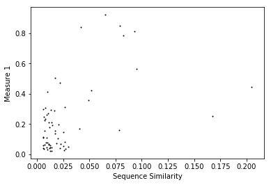

```python
if evlt.molecular_function_dataset(dataset_type):
    plot = evlt.plot_molecular_function(benchmark_dataset, measures[selected_measure])
    plot[0].set(xlabel = 'Sequence Similarity', ylabel=selected_measure)
    plot[1].set(xlabel = 'Molecular Function Similarity', ylabel=selected_measure)
else:
    plot = evlt.correlation_plot(benchmark_dataset, measures[selected_measure], dataset_type, selected_measure)
```

```python
if evlt.molecular_function_dataset(dataset_type):
    plot_pfam = evlt.plotting_molecular_function(benchmark_dataset, measures[selected_measure], selected_measure)
```

```python
if evlt.molecular_function_dataset(dataset_type):
    plot_seq = evlt.plotting_sequence(benchmark_dataset, measures[selected_measure], selected_measure)
```

### 5. Protein-protein interaction

In case you're dealing with a PPI dataset, it's possible to calculate how well the semantic similarity measures can predict Protein Protein Interactions. This module has two different functionalities:

1. Plot a Precision-Recall plot and find the highest F1-score. This is found by using 10-fold cross validation to test a range of different thresholds, selecting the best one, for each measure (state of the art and test).
2. Calculate precision, recall and F1-score for a given threshold (by changing the value of `thresh`). A dataframe and plot comparing precision, recall and F1-score for all semantic similarity measures at that threshold will be produced. The plot points color can be changed by adding the parameter `col`= [list of strings with size = number of measures], where each string is a valid color. You can also add `size` = `int` if you want to change the size of the plot points.

|  | metric | Measure 1 | Measure 2 | BMA Resnik | BMA Seco | GIC Resnik | GIC Seco |
| --- | --- | --- | --- | --- | --- | --- | --- |
| 0 | Best Threshold | 0.090000 | 0.080000 | 0.280000 | 0.370000 | 0.080000 | 0.090000 |
| 1 | Precision | 0.973684 | 0.973684 | 1.000000 | 0.950000 | 0.973684 | 0.973684 |
| 2 | Recall | 0.840909 | 0.840909 | 0.818182 | 0.863636 | 0.840909 | 0.840909 |
| 3 | F1-score | 0.902439 | 0.902439 | 0.900000 | 0.904762 | 0.902439 | 0.902439 |

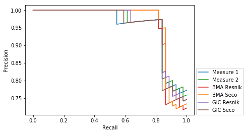

```python
if ppi.interaction_dataset(dataset_type):
        results = ppi.plot_precision_recall(benchmark_dataset, measures)
        display.display(results)
```

|  | metric | BMA Resnik | BMA Seco | GIC Resnik | GIC Seco | Measure 1 | Measure 2 |
| --- | --- | --- | --- | --- | --- | --- | --- |
| 0 | Precision | 0.745098 | 0.709677 | 1.000000 | 0.962963 | 0.960000 | 1.000000 |
| 1 | Recall | 0.863636 | 1.000000 | 0.590909 | 0.590909 | 0.545455 | 0.545455 |
| 2 | F-measure | 0.800000 | 0.830189 | 0.742857 | 0.732394 | 0.695652 | 0.705882 |

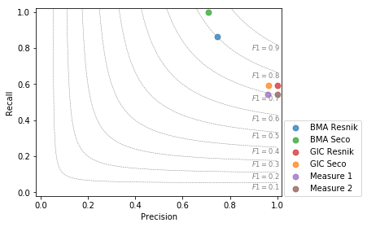

```python
#input your threshold of choice
thresh = 0.2

if ppi.interaction_dataset(dataset_type):
        df_f1 = ppi.get_f1_score_df(benchmark_dataset, measures, thresh)
        ppi.plot_f1(df_f1)
        display.display(df_f1)
```

#### Authors

- **Carlota Cardoso**
- **Rita Sousa**
- **Cátia Pesquita**

#### License

See the LICENSE.md file for details.

#### Acknowledgments

This project was funded by the Portuguese FCT through the LASIGE Research Unit (UID/CEC/00408/2019), and also by the SMILAX project (PTDC/EEI-ESS/4633/2014).